# Keras Tutorials

Michael Rose

## Intro

This is a work-through of the tutorials on the [Keras Homepage for R](https://keras.rstudio.com/index.html).

## Getting Started

### Check GPU Availability

```r
K = backend()
sess = K$get_session()
sess$list_devices()
```

```
## [[1]]
## _DeviceAttributes(/job:localhost/replica:0/task:0/device:CPU:0, CPU, 268435456, 964585524200714663)
##
## [[2]]
## _DeviceAttributes(/job:localhost/replica:0/task:0/device:XLA_CPU:0, XLA_CPU, 17179869184, 13276600141439894346)
##
## [[3]]
## _DeviceAttributes(/job:localhost/replica:0/task:0/device:GPU:0, GPU, 3607035904, 175599091932912688)
##
## [[4]]
## _DeviceAttributes(/job:localhost/replica:0/task:0/device:XLA_GPU:0, XLA_GPU, 17179869184, 18128805484851780537)
```

### MNIST Example

#### Preparing the Data

```r
# load data
mnist <- dataset_mnist()

x_train <- mnist$train$x
y_train <- mnist$train$y
x_test <- mnist$test$x
y_test <- mnist$test$y

# reshape into a single dimension
x_train <- array_reshape(x_train, c(nrow(x_train), 784))
x_test <- array_reshape(x_test, c(nrow(x_test), 784))

# rescale
x_train <- x_train / 255
x_test <- x_test / 255

# prepare labels for one hot encoding
y_train <- to_categorical(y_train, 10)
y_test <- to_categorical(y_test, 10)
```

#### Defining the Model

```r
# create sequential model
model <- keras_model_sequential()

# input length 784 numeric vector -> output length 10 numeric vector
model %>%
    layer_dense(units = 256, activation = "relu", input_shape = c(784)) %>%
    layer_dropout(rate = 0.4) %>%
    layer_dense(units = 128, activation = "relu") %>%
    layer_dropout(rate = 0.3) %>%
    layer_dense(units = 10, activation = "softmax")

# look at model details
model %>% summary()
```

```
## ___________________________________________________________________________
## Layer (type)                     Output Shape                  Param #
## ===========================================================================
## dense_116 (Dense)                (None, 256)                   200960
## ___________________________________________________________________________
## dropout_24 (Dropout)             (None, 256)                   0
## ___________________________________________________________________________
## dense_117 (Dense)                (None, 128)                   32896
## ___________________________________________________________________________
## dropout_25 (Dropout)             (None, 128)                   0
## ___________________________________________________________________________
## dense_118 (Dense)                (None, 10)                    1290
## ===========================================================================
## Total params: 235,146
## Trainable params: 235,146
## Non-trainable params: 0
## ___________________________________________________________________________
```

```r
# compile the model with loss function, optimizer, metrics
model %>% compile(
              loss = 'categorical_crossentropy',
              optimizer = optimizer_rmsprop(),
              metrics = c('accuracy')
)
```

#### Training and Evaluation

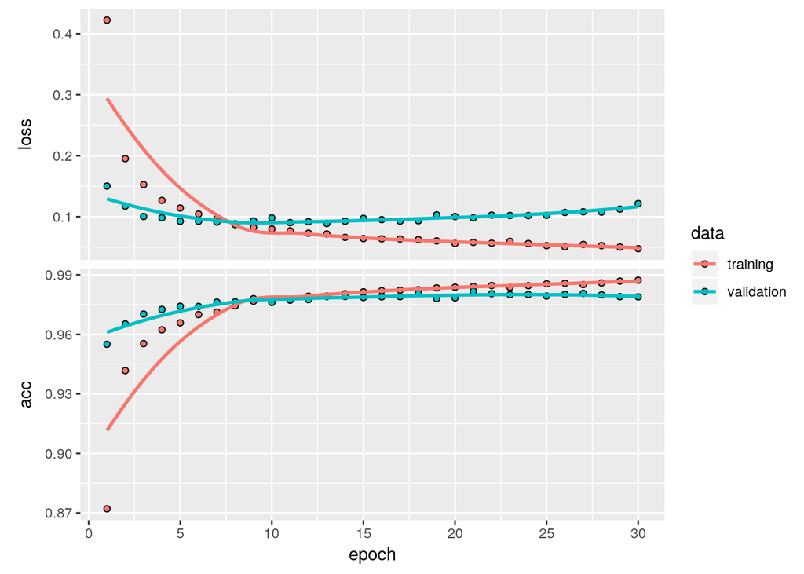

```r
# use fit to train model for 30 epochs using 128 image batches
history <- model %>% fit(
                         x_train, y_train,
                         epochs = 30,
                         batch_size = 128,
                         validation_split = 0.2
                     )

# plot
plot(history)
```

```r
# evaluate model on the test set
model %>% evaluate(x_test, y_test)
```

```
## $loss
## [1] 0.1115462
##
## $acc
## [1] 0.9806
```

```r
# generate predictions on new data
model %>% predict_classes(x_test) %>% head()
```

```
## [1] 7 2 1 0 4 1
```

## Basic Classification

### Fashion MNIST

```r
# load data
fashion_mnist <- dataset_fashion_mnist()

# create CV sets
c(train_images, train_labels) %<-% fashion_mnist$train
c(test_images, test_labels) %<-% fashion_mnist$test

# define class names
class_names <- c('T-shirt/top',
                'Trouser',
                'Pullover',
                'Dress',
                'Coat',
                'Sandal',
                'Shirt',
                'Sneaker',
                'Bag',
                'Ankle boot')
```

#### Explore the Data

```r
train_images %>% dim()
```

```
## [1] 60000    28    28
```

```r
test_images %>% dim()
```

```
## [1] 10000    28    28
```

```r
train_labels[1:20]
```

```
##  [1] 9 0 0 3 0 2 7 2 5 5 0 9 5 5 7 9 1 0 6 4
```

```r
test_labels[1:20]
```

```
##  [1] 9 2 1 1 6 1 4 6 5 7 4 5 7 3 4 1 2 4 8 0
```

#### Preprocess the Data

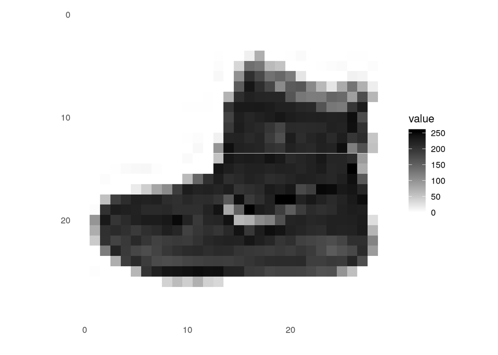

```r
library(tidyr)
library(ggplot2)

image_1 <- as.data.frame(train_images[1, , ])
colnames(image_1) <- seq_len(ncol(image_1))
image_1$y <- seq_len(nrow(image_1))
image_1 <- gather(image_1, "x", "value", -y)
image_1$x <- as.integer(image_1$x)

image_1 %>%
    ggplot(aes(x = x, y = y, fill = value)) +
    geom_tile() +
    scale_fill_gradient(low = "white", high = "black", na.value = NA) +
    scale_y_reverse() +
    theme_minimal() +
    theme(panel.grid = element_blank()) +
    theme(aspect.ratio = 1) +
    xlab("") + ylab("")
```

We scale these values to a range of 0 to 1 before feeding it to the neural network model. For this we divide by 255. It is important that the training and test sets are preprocessed in the same way.

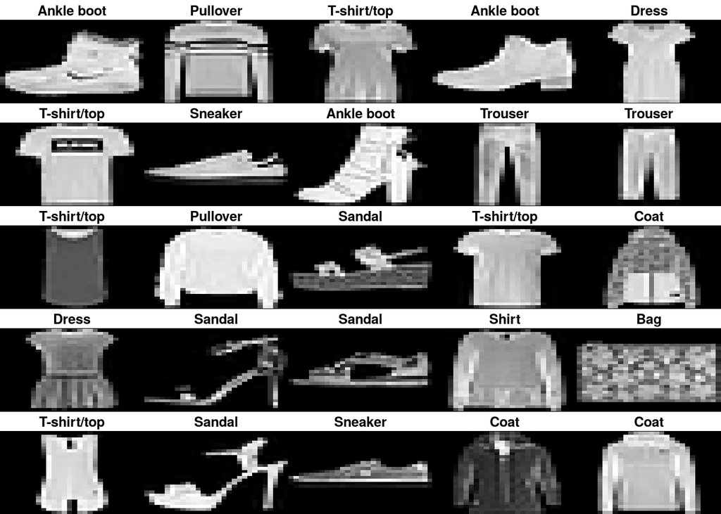

```r
# scale
train_images <- train_images / 255
test_images <- test_images / 255

# look at data
par(mfcol = c(5,5))
par(mar = c(0, 0, 1.5, 0), xaxs = 'i', yaxs = 'i')
for (i in 1:25) {
    img <- train_images[i, , ]
    img <- t(apply(img, 2, rev))
    image(1:28, 1:28, img, col = gray((0:255)/255), xaxt = 'n', yaxt = 'n',
          main = paste(class_names[train_labels[i] + 1]))
    }
```

#### Build the Model

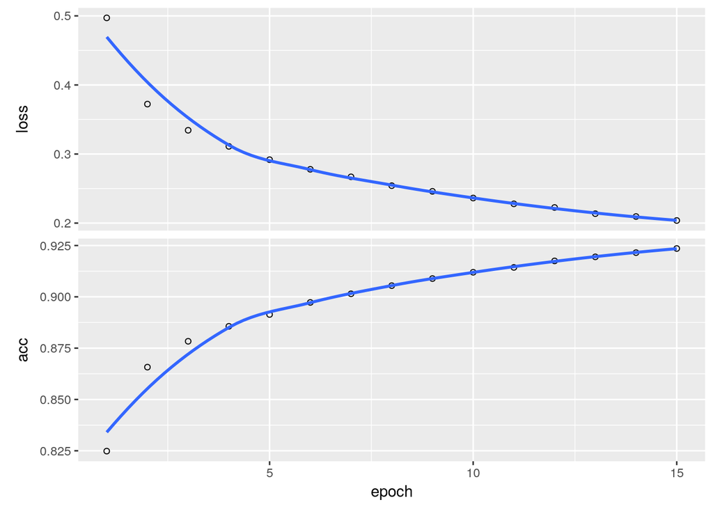

```r
model <- keras_model_sequential()

model %>%
    # transform 28x28 -> 784
    layer_flatten(input_shape = c(28, 28)) %>%
    layer_dense(units = 128, activation = "relu") %>%
    layer_dense(units = 10, activation = "softmax")

# compile
model %>% compile(
              optimizer = "adam",
              loss = "sparse_categorical_crossentropy",
              metrics = c("accuracy")
)

# train the model
history <- model %>% fit(train_images, train_labels, epochs = 15)

plot(history)
```

#### Evaluate Accuracy

```r
# eval model on test set
score <- model %>% evaluate(test_images, test_labels)
cat("Test Loss:", score$loss, "\n")
```

```
## Test Loss: 0.352304
```

```r
cat("Test Accuracy:", score$acc, "\n")
```

```
## Test Accuracy: 0.8906
```

```r
# make predictions
predictions <- model %>% predict(test_images)
predictions[1, ]
```

```
##  [1] 1.865897e-07 2.825205e-10 8.076169e-07 8.920596e-11 1.691643e-07
##  [6] 5.210166e-05 6.546814e-05 2.326190e-02 7.358969e-09 9.766194e-01
```

```r
# get best prediction from softmax array
which.max(predictions[1, ])
```

```
## [1] 10
```

```r
# directly get class prediction
class_pred <- model %>% predict_classes(test_images)
class_pred[1:20]
```

```
##  [1] 9 2 1 1 6 1 4 6 5 7 4 5 5 3 4 1 2 2 8 0
```

```r
# check if label is correct
test_labels[9]
```

```
## [1] 5
```

Lets plot some images with their predictions. Correct prediction labels are in green and incorrect prediction labels are in red.

[figure not shown]

```r
par(mfcol=c(5,5))
par(mar=c(0, 0, 1.5, 0), xaxs='i', yaxs='i')
for (i in 1:25) {
  img <- test_images[i, , ]
  img <- t(apply(img, 2, rev))
  # subtract 1 as labels go from 0 to 9
  predicted_label <- which.max(predictions[i, ]) - 1
  true_label <- test_labels[i]
  if (predicted_label == true_label) {
    color <- '#008800'
  } else {
    color <- '#bb0000'
  }
  image(1:28, 1:28, img, col = gray((0:255)/255), xaxt = 'n', yaxt = 'n',
        main = paste0(class_names[predicted_label + 1], " (",
                      class_names[true_label + 1], ")"),
        col.main = color)
}
```

Finally, use the trained model to make a prediction about a single image:

```r
img <- test_images[1, , , drop = FALSE]
img %>% dim()
```

```
## [1]  1 28 28
```

```r
# predict image
(predictions <- model %>% predict(img))
```

```
##              [,1]         [,2]        [,3]         [,4]         [,5]
## [1,] 1.865906e-07 2.825211e-10 8.07619e-07 8.920629e-11 1.691649e-07
##              [,6]         [,7]       [,8]         [,9]     [,10]
## [1,] 5.210175e-05 6.546838e-05 0.02326192 7.358997e-09 0.9766193
```

`predict` returns a list of lists, one for each image in the batch of data. Grab the predictions for our only image in the batch

```r
# subtract 1 as labels are 0-based
prediction <- predictions[1, ] - 1
which.max(prediction)
```

```
## [1] 10
```

## Text Classification

This tutorial classifies movie reviews as positive or negative.

```r
library(dplyr)
library(purrr)
```

### IMDB

#### Get Dataset

```r
# load data, max 10k words / review
imdb <- dataset_imdb(num_words = 10000)
c(train_data, train_labels) %<-% imdb$train
c(test_data, test_labels) %<-% imdb$test

# index mapping words to integers
word_index <- dataset_imdb_word_index()
```

#### Explore the Data

The data comes preprocessed; each example is an array of integers representing the words of the movie review. Each label is an integer value of either 0 or 1, where 0 is a negative review and 1 is a positive review.

```r
paste0("Training Entries: ", length(train_data), ", Labels: ", length(train_labels))
```

```
## [1] "Training Entries: 25000, Labels: 25000"
```

```r
# look at encoded text
train_data[[1]]
```

```
##   [1]    1   14   22   16   43  530  973 1622 1385   65  458 4468   66 3941
##  [15]    4  173   36  256    5   25  100   43  838  112   50  670    2    9
##  [29]   35  480  284    5  150    4  172  112  167    2  336  385   39    4
##  [43]  172 4536 1111   17  546   38   13  447    4  192   50   16    6  147
##  [57] 2025   19   14   22    4 1920 4613  469    4   22   71   87   12   16
##  [71]   43  530   38   76   15   13 1247    4   22   17  515   17   12   16
##  [85]  626   18    2    5   62  386   12    8  316    8  106    5    4 2223
##  [99] 5244   16  480   66 3785   33    4  130   12   16   38  619    5   25
## [113]  124   51   36  135   48   25 1415   33    6   22   12  215   28   77
## [127]   52    5   14  407   16   82    2    8    4  107  117 5952   15  256
## [141]    4    2    7 3766    5  723   36   71   43  530  476   26  400  317
## [155]   46    7    4    2 1029   13  104   88    4  381   15  297   98   32
## [169] 2071   56   26  141    6  194 7486   18    4  226   22   21  134  476
## [183]   26  480    5  144   30 5535   18   51   36   28  224   92   25  104
## [197]    4  226   65   16   38 1334   88   12   16  283    5   16 4472  113
## [211]  103   32   15   16 5345   19  178   32
```

Movie reviews may be different lengths. The code below shows the number of words in the first and second reviews. Since inputs to a neural network must be the same length, we need to resolve this later.

```r
length(train_data[[1]])
```

```
## [1] 218
```

```r
length(train_data[[2]])
```

```
## [1] 189
```

Lets convert the integers back to text to get a look at some of the data.

```r
word_index_df <- data.frame(
  word = names(word_index),
  idx = unlist(word_index, use.names = FALSE),
  stringsAsFactors = FALSE
)

# The first indices are reserved
word_index_df <- word_index_df %>% mutate(idx = idx + 3)
word_index_df <- word_index_df %>%
  add_row(word = "<PAD>", idx = 0)%>%
  add_row(word = "<START>", idx = 1)%>%
  add_row(word = "<UNK>", idx = 2)%>%
  add_row(word = "<UNUSED>", idx = 3)

word_index_df <- word_index_df %>% arrange(idx)

decode_review <- function(text){
  paste(map(text, function(number) word_index_df %>%
              filter(idx == number) %>%
              select(word) %>%
              pull()),
        collapse = " ")
}


# display text for first review
decode_review(train_data[[1]])
```

```
## [1] "<START> this film was just brilliant casting location scenery story direction everyone's really suited the part they played and you could just imagine being there robert <UNK> is an amazing actor and now the same being director <UNK> father came from the same scottish island as myself so i l…
```

#### Prepare the Data

The reviews (arrays of integers) must be converted to tensors before being fed into the neural network. This can be done in the following ways:

- One hot encode the arrays to convert them into vectors of 0s and 1s. This approach is memory intensive.
- Pad the arrays so they all have the same length, then create an integer tensor. We can use an embedding layer capable of handling this shape as the first layer in the network. We will use this approach in this tutorial.

```r
train_data <- pad_sequences(
    train_data,
    value = word_index_df %>%
        filter(word == "<PAD>") %>%
        select(idx) %>%
        pull(),
    padding = "post",
    maxlen = 256
)

test_data <- pad_sequences(
    test_data,
    value = word_index_df %>%
        filter(word == "<PAD>") %>%
        select(idx) %>%
        pull(),
    padding = "post",
    maxlen = 256
)
```

Let’s look at the length of the examples now:

```r
length(train_data[1, ])
```

```
## [1] 256
```

```r
length(train_data[2, ])
```

```
## [1] 256
```

and look at the padded first review

```r
train_data[1,]
```

```
##   [1]    1   14   22   16   43  530  973 1622 1385   65  458 4468   66 3941
##  [15]    4  173   36  256    5   25  100   43  838  112   50  670    2    9
##  [29]   35  480  284    5  150    4  172  112  167    2  336  385   39    4
##  [43]  172 4536 1111   17  546   38   13  447    4  192   50   16    6  147
##  [57] 2025   19   14   22    4 1920 4613  469    4   22   71   87   12   16
##  [71]   43  530   38   76   15   13 1247    4   22   17  515   17   12   16
##  [85]  626   18    2    5   62  386   12    8  316    8  106    5    4 2223
##  [99] 5244   16  480   66 3785   33    4  130   12   16   38  619    5   25
## [113]  124   51   36  135   48   25 1415   33    6   22   12  215   28   77
## [127]   52    5   14  407   16   82    2    8    4  107  117 5952   15  256
## [141]    4    2    7 3766    5  723   36   71   43  530  476   26  400  317
## [155]   46    7    4    2 1029   13  104   88    4  381   15  297   98   32
## [169] 2071   56   26  141    6  194 7486   18    4  226   22   21  134  476
## [183]   26  480    5  144   30 5535   18   51   36   28  224   92   25  104
## [197]    4  226   65   16   38 1334   88   12   16  283    5   16 4472  113
## [211]  103   32   15   16 5345   19  178   32    0    0    0    0    0    0
## [225]    0    0    0    0    0    0    0    0    0    0    0    0    0    0
## [239]    0    0    0    0    0    0    0    0    0    0    0    0    0    0
## [253]    0    0    0    0
```

#### Build the Model

```r
# input shape is the vocabulary count used for the movie reviews
vocab_size <- 10000

model <- keras_model_sequential()

model %>%
    layer_embedding(input_dim = vocab_size, output_dim = 16) %>%
    layer_global_average_pooling_1d() %>%
    layer_dense(units = 16, activation = "relu") %>%
    layer_dense(units = 1, activation = "sigmoid")

model %>% summary()
```

```
## ___________________________________________________________________________
## Layer (type)                     Output Shape                  Param #
## ===========================================================================
## embedding_5 (Embedding)          (None, None, 16)              160000
## ___________________________________________________________________________
## global_average_pooling1d_5 (Glob (None, 16)                    0
## ___________________________________________________________________________
## dense_121 (Dense)                (None, 16)                    272
## ___________________________________________________________________________
## dense_122 (Dense)                (None, 1)                     17
## ===========================================================================
## Total params: 160,289
## Trainable params: 160,289
## Non-trainable params: 0
## ___________________________________________________________________________
```

- The first layer is an embedding layer that takes the integer encoded vocabulary and looks up the embedding vector for each word index.
- The global average pooling 1d layer returns a fixed length output vector for each example by averaging over the sequence dimension. This allows the model to handle input of variable length in a simple manner.
- The last layer is a densely connected single output node with a sigmoid activation function.

```r
# compile the model
model %>% compile(
              optimizer = "adam",
              loss = "binary_crossentropy",
              metrics = list("accuracy")
          )
```

#### Create a Validation Set

```r
x_val <- train_data[1:10000, ]
partial_x_train <- train_data[10001:nrow(train_data), ]

y_val <- train_labels[1:10000]
partial_y_train <- train_labels[10001:length(train_labels)]
```

#### Train the Model

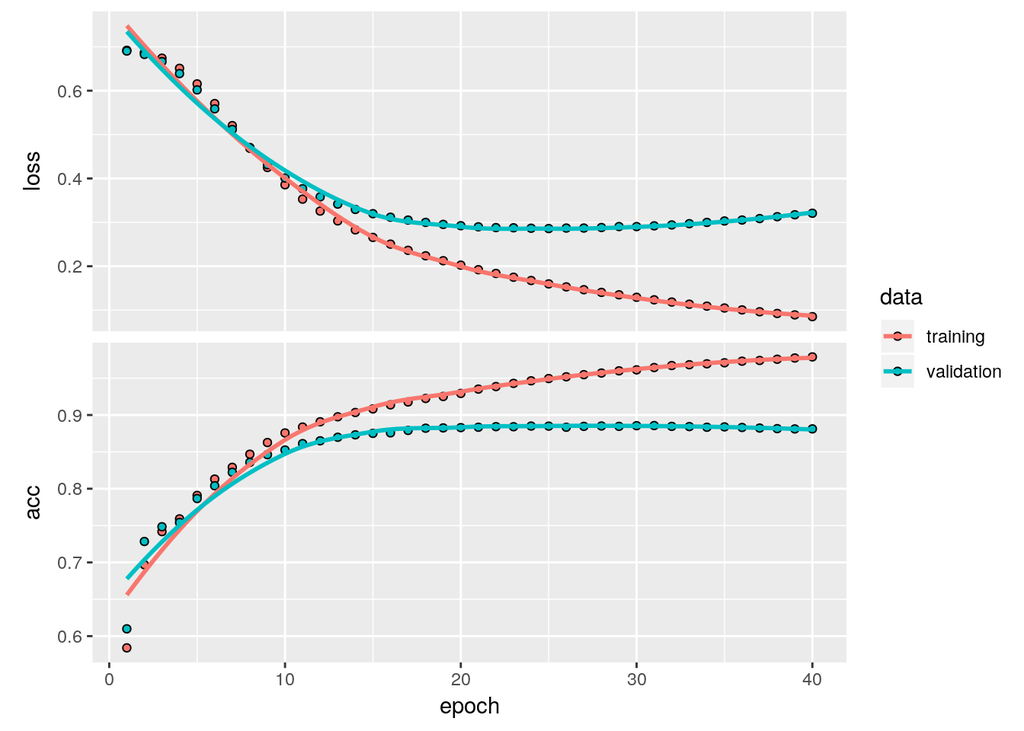

```r
history <- model %>% fit(
                         partial_x_train,
                         partial_y_train,
                         epochs = 40,
                         batch_size = 512,
                         validation_data = list(x_val, y_val),
                         verbose = 1
                     )

plot(history)
```

#### Evaluate the Model

```r
results <- model %>% evaluate(test_data, test_labels)
```

## Basic Regression

This segment builds a regression model to predict the median price of homes in a Boston suburb during the mid 1970s.

```r
# get data
boston_housing <- dataset_boston_housing()

c(train_data, train_labels) %<-% boston_housing$train
c(test_data, test_labels) %<-% boston_housing$test
```

This dataset is much smaller than a usual keras usecase.

```r
paste0("Training entries: ", length(train_data), ", labels: ", length(train_labels))
```

```
## [1] "Training entries: 5252, labels: 404"
```

The dataset contains 13 different features:

- Per capita crime rate.
- The proportion of residential land zoned for lots over 25,000 square feet.
- The proportion of non-retail business acres per town.
- Charles River dummy variable (= 1 if tract bounds river; 0 otherwise).
- Nitric oxides concentration (parts per 10 million).
- The average number of rooms per dwelling.
- The proportion of owner-occupied units built before 1940.
- Weighted distances to five Boston employment centers.
- Index of accessibility to radial highways.
- Full-value property-tax rate per $10,000.
- Pupil-teacher ratio by town.
- 1000 * (Bk - 0.63) ** 2 where Bk is the proportion of Black people by town.
- Percentage lower status of the population.

```r
train_data %>% head(1)
```

```
##         [,1] [,2] [,3] [,4]  [,5]  [,6] [,7]   [,8] [,9] [,10] [,11] [,12]
## [1,] 1.23247    0 8.14    0 0.538 6.142 91.7 3.9769    4   307    21 396.9
##      [,13]
## [1,] 18.72
```

We can add column names for better data inspection.

```r
library(tibble)

column_names <- c('CRIM', 'ZN', 'INDUS', 'CHAS', 'NOX', 'RM', 'AGE',
                  'DIS', 'RAD', 'TAX', 'PTRATIO', 'B', 'LSTAT')

train_df <- as_tibble(train_data)

colnames(train_df) <- column_names

train_df %>% head()
```

| CRIM | ZN | INDUS | CHAS | NOX | RM | AGE | DIS | RAD | TAX | PTRATIO | B | LSTAT |
| --- | --- | --- | --- | --- | --- | --- | --- | --- | --- | --- | --- | --- |
| 1.23247 | 0.0 | 8.14 | 0 | 0.538 | 6.142 | 91.7 | 3.9769 | 4 | 307 | 21.0 | 396.90 | 18.72 |
| 0.02177 | 82.5 | 2.03 | 0 | 0.415 | 7.610 | 15.7 | 6.2700 | 2 | 348 | 14.7 | 395.38 | 3.11 |
| 4.89822 | 0.0 | 18.10 | 0 | 0.631 | 4.970 | 100.0 | 1.3325 | 24 | 666 | 20.2 | 375.52 | 3.26 |
| 0.03961 | 0.0 | 5.19 | 0 | 0.515 | 6.037 | 34.5 | 5.9853 | 5 | 224 | 20.2 | 396.90 | 8.01 |
| 3.69311 | 0.0 | 18.10 | 0 | 0.713 | 6.376 | 88.4 | 2.5671 | 24 | 666 | 20.2 | 391.43 | 14.65 |
| 0.28392 | 0.0 | 7.38 | 0 | 0.493 | 5.708 | 74.3 | 4.7211 | 5 | 287 | 19.6 | 391.13 | 11.74 |

The labels are the house prices in thousands of dollars. Note the 1970’s prices.

```r
train_labels[1:10]
```

```
##  [1] 15.2 42.3 50.0 21.1 17.7 18.5 11.3 15.6 15.6 14.4
```

#### Normalize Features

It’s recommended to normalize features that use different scales and ranges.

```r
# normalize training data
train_data <- scale(train_data)

# use means and SDs from training to normalize test set
col_means_train <- attr(train_data, "scaled:center")
col_stddevs_train <- attr(train_data, "scaled:scale")

test_data <- scale(test_data, center = col_means_train, scale = col_stddevs_train)

# look at first training sample normalized
train_data[1,]
```

```
##  [1] -0.2719092 -0.4830166 -0.4352220 -0.2565147 -0.1650220 -0.1762241
##  [7]  0.8120550  0.1165538 -0.6254735 -0.5944330  1.1470781  0.4475222
## [13]  0.8241983
```

#### Create the Model

```r
build_model <- function() {
    model <- keras_model_sequential() %>%
        layer_dense(units = 64, activation = "relu",
                    input_shape = dim(train_data)[2]) %>%
        layer_dense(units = 64, activation = "relu") %>%
        layer_dense(units = 1)

    model %>% compile(
                  loss = "mse",
                  optimizer = optimizer_rmsprop(),
                  metrics = list("mean_absolute_error")
              )

    model
}

model <- build_model()

model %>% summary()
```

```
## ___________________________________________________________________________
## Layer (type)                     Output Shape                  Param #
## ===========================================================================
## dense_123 (Dense)                (None, 64)                    896
## ___________________________________________________________________________
## dense_124 (Dense)                (None, 64)                    4160
## ___________________________________________________________________________
## dense_125 (Dense)                (None, 1)                     65
## ===========================================================================
## Total params: 5,121
## Trainable params: 5,121
## Non-trainable params: 0
## ___________________________________________________________________________
```

#### Train the Model

The model is trained for 500 epochs. It is also showed how to use a custom callback, replacing the default training output by a single dot per epoch.

```r
print_dot_callback <- callback_lambda(
    on_epoch_end = function(epoch, logs) {
        if (epoch %% 80 == 0) cat("\n")
        cat(".")
    }
)

epochs <- 500

# fit the model and store training stats
history <- model %>% fit(
                         train_data,
                         train_labels,
                         epochs = epochs,
                         validation_split = 0.2,
                         verbose = 0,
                         callbacks = list(print_dot_callback)
                     )
```

```
##
## ................................................................................
## ................................................................................
## ................................................................................
## ................................................................................
## ................................................................................
## ................................................................................
## ....................
```

Now we can visualize the model’s training progress using the metrics stored in the history variable.

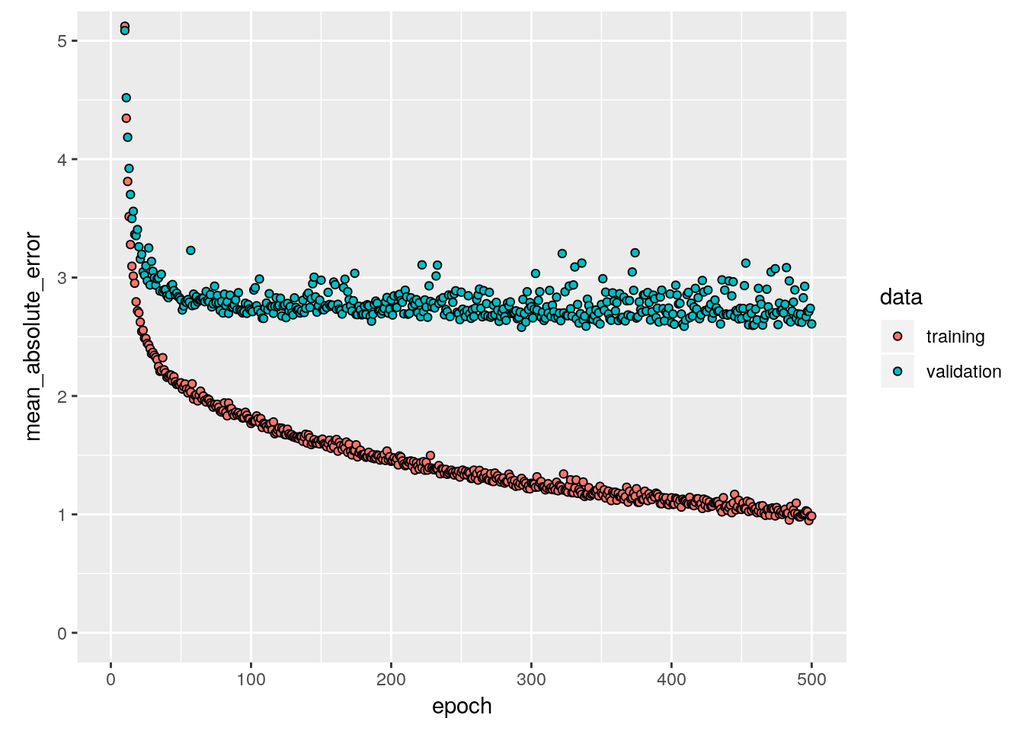

```r
library(ggplot2)

plot(history, metrics = "mean_absolute_error", smooth = FALSE) +
    coord_cartesian(ylim = c(0, 5))
```

This graph shows little improvement in the model after 200 epochs. Let’s update the fit method to automatically stop training when the validation score doesn’t improve. We’ll use a callback that tests a training condition for every epoch. If a set of epochs elapses without showing any improvement, it automatically stops the training.

```r
# the patience parameter is the amount of epochs to check for improvement
early_stop <- callback_early_stopping(monitor = "val_loss", patience = 20)

model <- build_model()

history <- model %>% fit(
                         train_data,
                         train_labels,
                         epochs = epochs,
                         validation_split = 0.2,
                         verbose = 0,
                         callbacks = list(early_stop, print_dot_callback)
                     )
```

```
##
## .................................................................
```

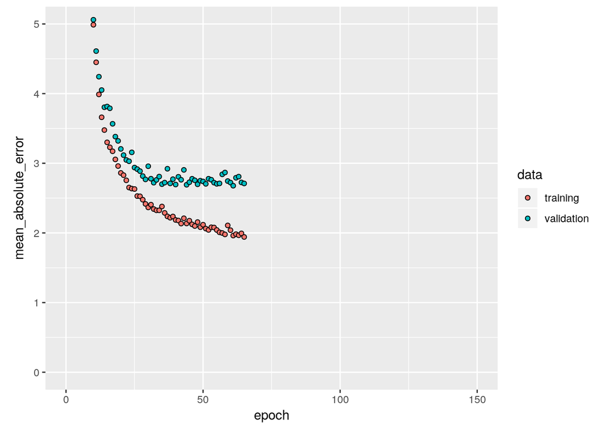

```r
plot(history, metrics = "mean_absolute_error", smooth = FALSE) +
    coord_cartesian(xlim = c(0, 150), ylim = c(0, 5))
```

This graph shows the average error is about $2500. This is not insignificant when some of the labels are only $15000.

```r
# check how model performs on the test set
c(loss, mae) %<-% (model %>% evaluate(test_data, test_labels, verbose = 0))

paste0("Mean absolute error on test set: $", sprintf("%.2f", mae * 1000))
```

```
## [1] "Mean absolute error on test set: $3135.30"
```

#### Predict

Finally, let’s predict some housing prices using data in the testing set:

```r
test_predictions <- model %>% predict(test_data)

test_predictions[, 1]
```

```
##   [1]  7.943353 17.624496 21.503904 32.147198 25.998516 19.408178 27.042011
##   [8] 22.664116 19.663246 22.953539 18.742477 17.340714 15.265718 42.853359
##  [15] 19.581980 19.476686 27.429306 23.024796 20.628063 37.263378 12.205917
##  [22] 15.626458 21.177944 14.344106 20.974152 25.760998 30.673279 30.373245
##  [29] 10.346097 21.959873 18.814447 14.187318 32.755585 25.717409 18.395790
##  [36]  9.005435 14.977125 16.466162 20.944183 27.189911 29.810061 29.105289
##  [43] 14.785565 39.803658 31.603523 25.508541 26.828188 16.225317 24.609541
##  [50] 22.381203 36.545738 20.152372 12.212179 16.101128 33.257912 28.705681
##  [57] 12.442443 47.038544 33.487221 23.712221 25.109329 17.497734 14.638413
##  [64] 18.126808 23.932318 22.175701 12.506008 22.805460 14.135284  7.152385
##  [71] 36.777264 30.470076 27.205379 14.318246 24.739466 17.486172 20.868092
##  [78] 23.422256 35.267780 10.924888 19.880119 38.186932 14.814722 13.721466
##  [85] 17.179703 17.834354 21.796335 20.713398 22.633106 31.736174 19.274494
##  [92] 20.097908 25.309397 41.629688 35.292511 18.164562 36.244297 51.716061
##  [99] 26.994370 44.901688 32.301140 19.603079
```

#### Conclusion

This notebook introduced a few techniques to handle a regression problem.

- Mean Squared Error is a common loss function for regression problems
- A common regression metric is mean absolute error
- When input data features have different ranges, each feature should be scaled independently
- If there is not much training data, prefer a small network with few hidden layers to avoid overfitting
- early stopping is a useful technique to prevent overfitting

## Overfitting / Underfitting

In previous tabs we saw that often our model would overfit to the training data. The best solution to overfitting is to get more data. A model trained on more data will naturally generalize better. When that is not possible, the next best solution is to use techniques like regularization. These place constraints on the quantity and type of information our model can store. If a network can only afford to focus on a small number of patterns, the optimization process will force it to focus on the most prominent patterns, which have a better chance of generalizing well.

In this section we will explore two common regularization techniques - weight regularization and dropout.

```r
num_words <- 10000
imdb <- dataset_imdb(num_words = num_words)

c(train_data, train_labels) %<-% imdb$train
c(test_data, test_labels) %<-% imdb$test
```

Rather than using embedding like the previous section, here we will multi hot encode the sentences. This model will quickly overfit to the training set. It will be used to demonstrate when overfitting occurs and how to fight it.

Multi-hot encoding our lists means turning them into vectors of 0s and 1s. Concretely, this would mean, for instance, turning the sequence [3, 5] into a 10,000 dimensional vector that would be all zeros except for indices 3 and 5, which would be ones.

```r
multi_hot_sequences <- function(sequences, dimension) {
    multi_hot <- matrix(0, nrow = length(sequences), ncol = dimension)

    for (i in 1:length(sequences)) {
        multi_hot[i, sequences[[i]]] <- 1
    }
    multi_hot
}

train_data <- multi_hot_sequences(train_data, num_words)
test_data <- multi_hot_sequences(test_data, num_words)
```

Let’s look at one of the resulting multihot vectors. The word indices are sorted by frequency, so it is expected that there are more 1-values near index zero, as we can see in this plot:

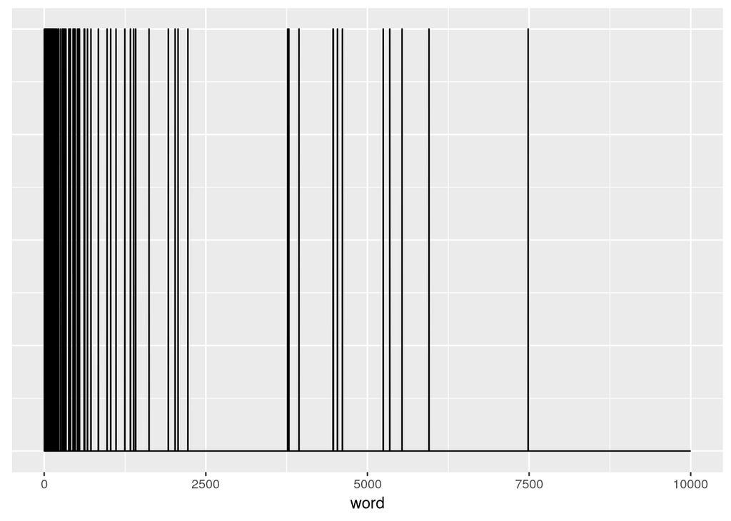

```r
first_text <- data.frame(word = 1:10000, value = train_data[1, ])

first_text %>%
    ggplot(aes(x = word, y = value)) +
    geom_line() +
    theme(axis.title.y = element_blank(),
          axis.text.y = element_blank(),
          axis.ticks.y = element_blank())
```

#### Demonstrate Overfitting

In order to demonstrate overfitting, first we will create a simple model using only dense layers, then a smaller version and compare them.

```r
# create a baseline model
baseline_model <- keras_model_sequential() %>%
    layer_dense(units = 16, activation = "relu", input_shape = 10000) %>%
    layer_dense(units = 16, activation = "relu") %>%
    layer_dense(units = 1, activation = "sigmoid")

baseline_model %>% compile(
                       optimizer = "adam",
                       loss = "binary_crossentropy",
                       metrics = list("accuracy")
                   )

baseline_model %>% summary()
```

```
## ___________________________________________________________________________
## Layer (type)                     Output Shape                  Param #
## ===========================================================================
## dense_129 (Dense)                (None, 16)                    160016
## ___________________________________________________________________________
## dense_130 (Dense)                (None, 16)                    272
## ___________________________________________________________________________
## dense_131 (Dense)                (None, 1)                     17
## ===========================================================================
## Total params: 160,305
## Trainable params: 160,305
## Non-trainable params: 0
## ___________________________________________________________________________
```

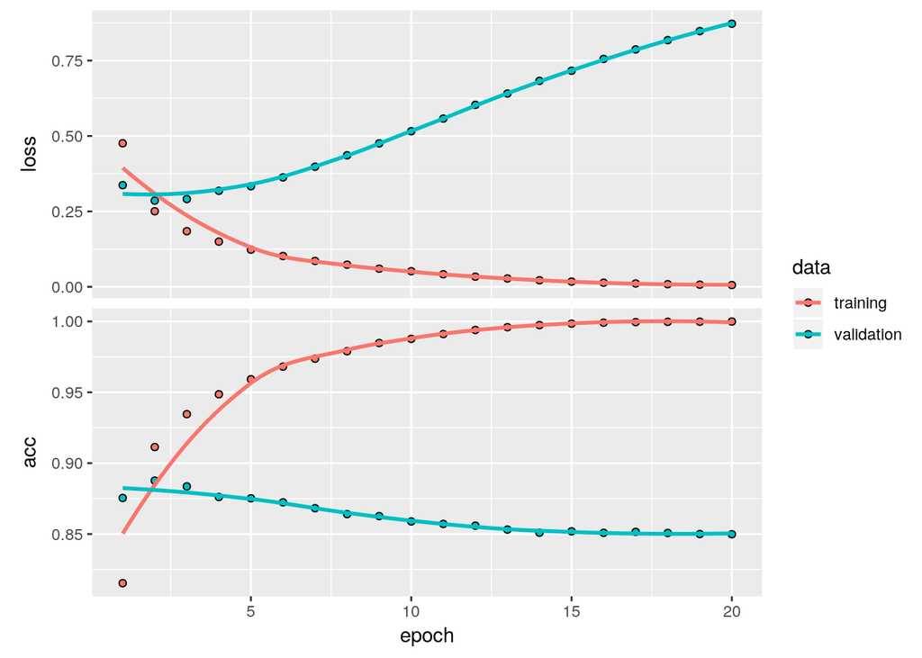

```r
baseline_history <- baseline_model %>% fit(
                                           train_data,
                                           train_labels,
                                           epochs = 20,
                                           batch_size = 512,
                                           validation_data = list(test_data, test_labels),
                                           verbose = 2
                                       )

plot(baseline_history)
```

```r
# create a smaller model to compare
smaller_model <- keras_model_sequential() %>%
    layer_dense(units = 4, activation = "relu", input_shape = 10000) %>%
    layer_dense(units = 4, activation = "relu") %>%
    layer_dense(units = 1, activation = "sigmoid")

smaller_model %>% compile(
                      optimizer = "adam",
                      loss = "binary_crossentropy",
                      metrics = list("accuracy")
                  )

smaller_model %>% summary()
```

```
## ___________________________________________________________________________
## Layer (type)                     Output Shape                  Param #
## ===========================================================================
## dense_132 (Dense)                (None, 4)                     40004
## ___________________________________________________________________________
## dense_133 (Dense)                (None, 4)                     20
## ___________________________________________________________________________
## dense_134 (Dense)                (None, 1)                     5
## ===========================================================================
## Total params: 40,029
## Trainable params: 40,029
## Non-trainable params: 0
## ___________________________________________________________________________
```

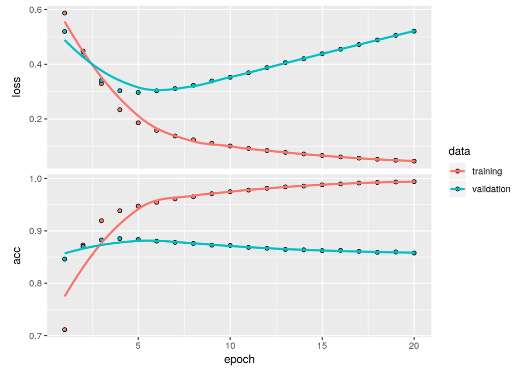

```r
# train the model using the same data
smaller_history <- smaller_model %>% fit(
                                         train_data,
                                         train_labels,
                                         epochs = 20,
                                         batch_size = 512,
                                         validation_data = list(test_data, test_labels),
                                         verbose = 2
                                     )

plot(smaller_history)
```

Now, let’s add to this benchmark a network that has much more capacity, far more than the problem would warrant:

```r
# create a bigger model
bigger_model <- keras_model_sequential() %>%
    layer_dense(units = 512, activation = "relu", input_shape = 10000) %>%
    layer_dense(units = 512, activation = "relu") %>%
    layer_dense(units = 1, activation = "sigmoid")

bigger_model %>% compile(
                     optimizer = "adam",
                     loss = "binary_crossentropy",
                     metrics = list("accuracy")
                 )

bigger_model %>% summary()
```

```
## ___________________________________________________________________________
## Layer (type)                     Output Shape                  Param #
## ===========================================================================
## dense_135 (Dense)                (None, 512)                   5120512
## ___________________________________________________________________________
## dense_136 (Dense)                (None, 512)                   262656
## ___________________________________________________________________________
## dense_137 (Dense)                (None, 1)                     513
## ===========================================================================
## Total params: 5,383,681
## Trainable params: 5,383,681
## Non-trainable params: 0
## ___________________________________________________________________________
```

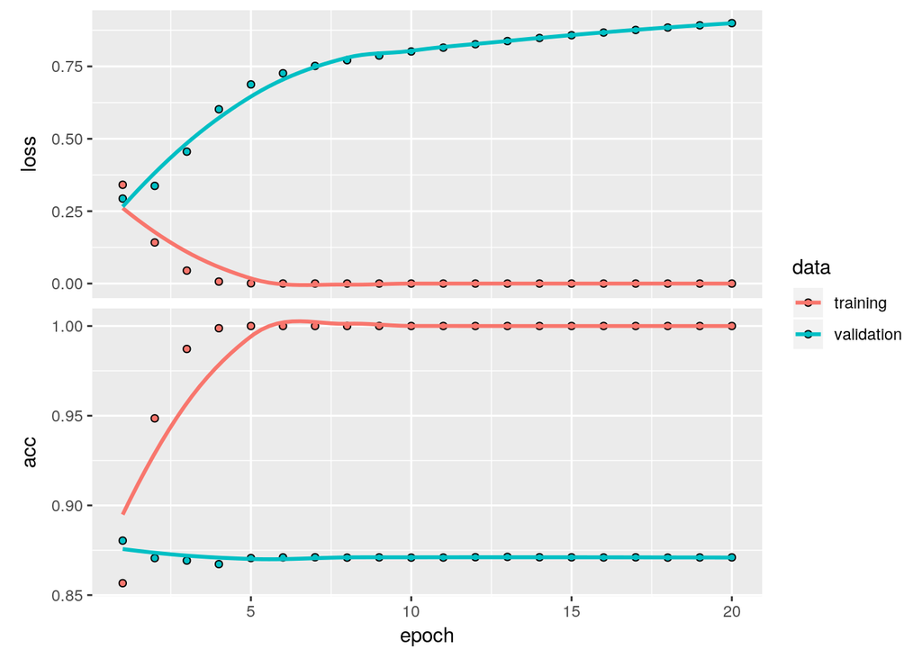

```r
bigger_history <- bigger_model %>% fit(
                                       train_data,
                                       train_labels,
                                       epochs = 20,
                                       batch_size = 512,
                                       validation_data = list(test_data, test_labels),
                                       verbose = 2
                                   )

plot(bigger_history)
```

##### Plot the Training and Validation Loss

Now let’s plot the loss curves for the 3 models.

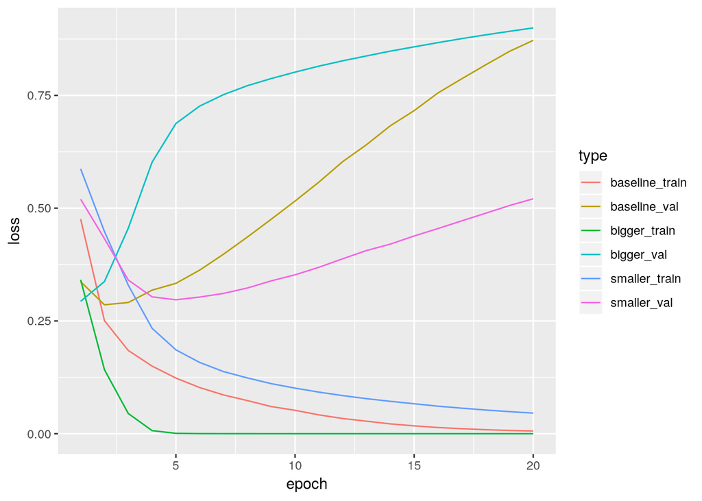

```r
compare_cx <- data.frame(
    baseline_train = baseline_history$metrics$loss,
    baseline_val = baseline_history$metrics$val_loss,
    smaller_train = smaller_history$metrics$loss,
    smaller_val = smaller_history$metrics$val_loss,
    bigger_train = bigger_history$metrics$loss,
    bigger_val = bigger_history$metrics$val_loss
) %>%
    rownames_to_column() %>%
    mutate(rowname = as.integer(rowname)) %>%
    gather(key = "type", value = "value", -rowname)

compare_cx %>%
    ggplot(aes(x = rowname, y = value, color = type)) +
    geom_line() +
    xlab("epoch") + ylab("loss")
```

#### Strategies

This section will focus on **Weight Regularization** and **Dropout**.

##### Weight Regularization

Given some training data and a network architecture, there are multiple sets of weights values (multiple models) that could explain the data, and simpler models are less likely to overfit than complex ones.

A “simpler model” in this context is a model where the distribution of parameter values has less entropy (or a model with fewer parameters altogether). Thus, a common way to mitigate overfitting is to put constraints on the complexity of a network by forcing its weights to only take on small values, which makes the distribution of weight values more regular. This is called weight regularization, and it is done by adding to the loss function of the network a cost associated with having large weights.

This cost comes in two flavors:

- L1 regularization, where the cost added is proportional to the absolute value of the weights coefficients (the L1 norm of the weights).
- L2 regularization, where the cost added is proportional to the square of the value of the weights coefficients (the L2 norm of the weights). L2 regularization is also called weight decay in the context of neural networks.

In Keras, weight regularization is added by passing weight regularizer instances to layers.

```r
L2_model <- keras_model_sequential() %>%
    layer_dense(units = 16, activation = "relu", input_shape = 10000,
                kernel_regularizer = regularizer_l2(l = 0.001)) %>%
    layer_dense(units = 16, activation = "relu",
                kernel_regularizer = regularizer_l2(l = 0.001)) %>%
    layer_dense(units = 1, activation = "sigmoid")

L2_model %>% compile(
                 optimizer = "adam",
                 loss = "binary_crossentropy",
                 metrics = list("accuracy")
             )

L2_history <- L2_model %>% fit(
                               train_data,
                               train_labels,
                               epochs = 20,
                               batch_size = 512,
                               validation_data = list(test_data, test_labels),
                               verbose = 2
                           )
```

`l2(0.001)` means that every coefficient in the weight matrix of the layer will ad 0.001 * `weight_coefficient_value` to the total loss of the network. Note that because this penalty is only added at training time, the loss for this network will be much higher at training than at test time.

Here is the impact of our L2 regularization penalty:

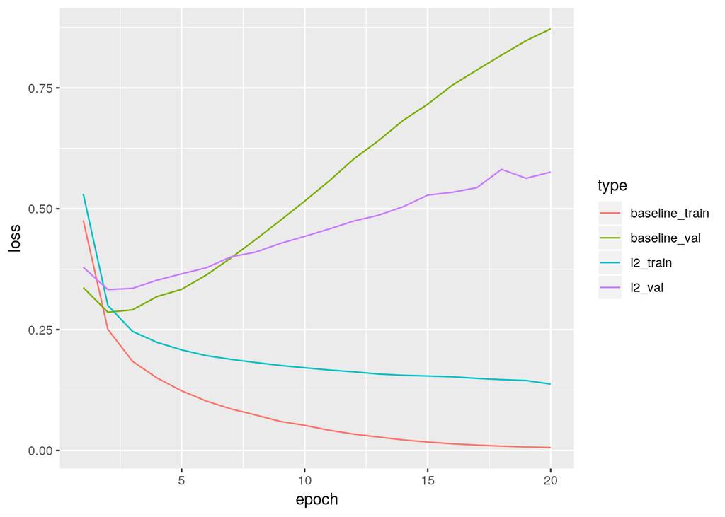

```r
compare_cx <- data.frame(
  baseline_train = baseline_history$metrics$loss,
  baseline_val = baseline_history$metrics$val_loss,
  l2_train = L2_history$metrics$loss,
  l2_val = L2_history$metrics$val_loss
) %>%
  rownames_to_column() %>%
  mutate(rowname = as.integer(rowname)) %>%
  gather(key = "type", value = "value", -rowname)

compare_cx %>%
    ggplot(aes(x = rowname, y = value, color = type)) +
    geom_line() +
    xlab("epoch") + ylab("loss")
```

As can be seen above, the L2 regularized model has become more resistant to overfitting than the baseline odel, even though both models have the same number of parameters.

##### Dropout

Dropout consists of randomly dropping out (set to zero) a number of output features of the layer during training. Let’s say taht a given layer would normally have returned a vector for a given input sample during training. After applying dropout, this vector will have a few zero entries distributed at random.

In Keras, we can apply dropout via the `layer_dropout`, which gets applied to the output of the layer directly before.

```r
dropout_model <- keras_model_sequential() %>%
    layer_dense(units = 16, activation = "relu", input_shape = 10000) %>%
    layer_dropout(0.6) %>%
    layer_dense(units = 16, activation = "relu") %>%
    layer_dropout(0.6) %>%
    layer_dense(units = 1, activation = "sigmoid")

dropout_model %>% compile(
                      optimizer = "adam",
                      loss = "binary_crossentropy",
                      metrics = list("accuracy")
                  )

dropout_history <- dropout_model %>% fit(
                                         train_data,
                                         train_labels,
                                         epochs = 20,
                                         batch_size = 512,
                                         validation_data = list(test_data, test_labels),
                                         verbose = 2
                                     )
```

Let’s see how well it worked

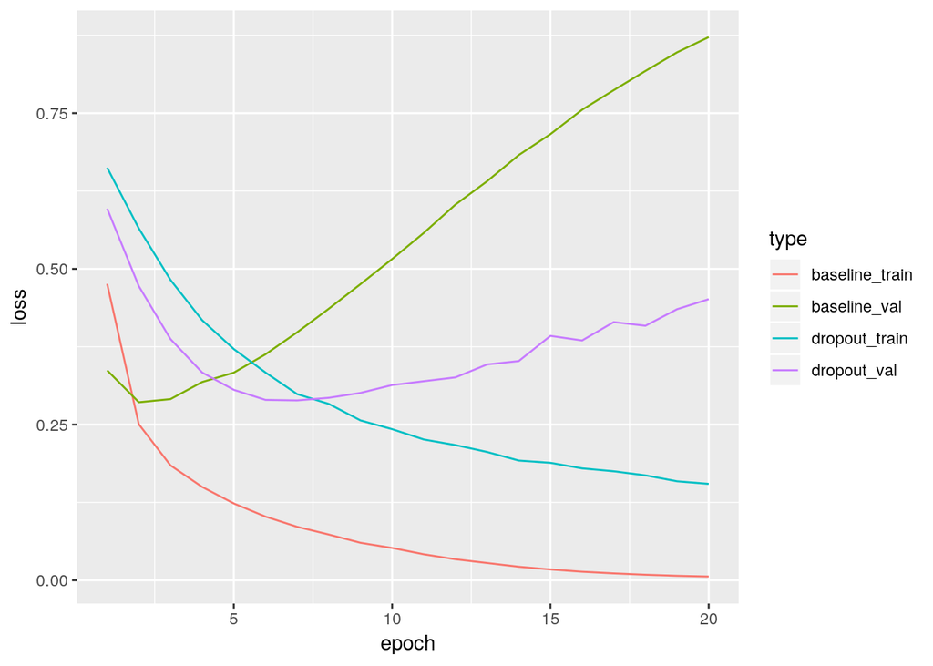

```r
compare_cx <- data.frame(
  baseline_train = baseline_history$metrics$loss,
  baseline_val = baseline_history$metrics$val_loss,
  dropout_train = dropout_history$metrics$loss,
  dropout_val = dropout_history$metrics$val_loss
) %>%
  rownames_to_column() %>%
  mutate(rowname = as.integer(rowname)) %>%
  gather(key = "type", value = "value", -rowname)

compare_cx %>%
    ggplot(aes(x = rowname, y = value, color = type)) +
    geom_line() +
    xlab("epoch") +
    ylab("loss")
```

Adding dropout is a clear improvement over the baseline model.

To recap:

Here are the most common ways to prevent overfitting in neural networks:

- get more training data
- reduce the capacity of the network
- add weight regularization
- add dropout

Two more approaches not covered here are data augmentation and batch normalization.

## Save / Restore Models

Model progress can be saved after, as well as during training.

We’ll use the MNIST data to train our model and demonstrate saving weights. To speed up these demonstration runs, we will only use the first 1000 examples.

```r
mnist <- dataset_mnist()

c(train_images, train_labels) %<-% mnist$train
c(test_images, test_labels) %<-% mnist$test

train_labels <- train_labels[1:1000]
test_labels <- test_labels[1:1000]

train_images <- train_images[1:1000, , ] %>%
    array_reshape(c(1000, 28 * 28))

train_images <- train_images / 255

test_images <- test_images[1:1000, , ] %>%
    array_reshape(c(1000, 28 * 28))

test_images <- test_images / 255
```

##### Define a Model

```r
# returns a short sequential model
create_model <- function() {
    model <- keras_model_sequential() %>%
        layer_dense(units = 512, activation = "relu", input_shape = 784) %>%
        layer_dropout(0.2) %>%
        layer_dense(units = 10, activation = "softmax")

    model %>% compile(
                  optimizer = "adam",
                  loss = "sparse_categorical_crossentropy",
                  metrics = list("accuracy")
              )
    model
}


model <- create_model()

model %>% summary()
```

```
## ___________________________________________________________________________
## Layer (type)                     Output Shape                  Param #
## ===========================================================================
## dense_144 (Dense)                (None, 512)                   401920
## ___________________________________________________________________________
## dropout_28 (Dropout)             (None, 512)                   0
## ___________________________________________________________________________
## dense_145 (Dense)                (None, 10)                    5130
## ===========================================================================
## Total params: 407,050
## Trainable params: 407,050
## Non-trainable params: 0
## ___________________________________________________________________________
```

#### Save the Entire Model

The habitual form of saving a keras model is aving to the HDF5 format.

The resulting file contains weights, configuration, and the optimizers configuration. This allows us to resume training later, from the exact state.

```r
model %>% fit(
              train_images,
              train_labels,
              epochs = 5
          )

model %>% save_model_hdf5("my_model.h5")
```

If we only wanted to save the weights, we could replace the last line with

```r
model %>% save_model_weights_hdf5("my_model_weights.h5")
```

Now recreate the model from that file:

```r
new_model <- load_model_hdf5("my_model.h5")

new_model %>% summary()
```

```
## ___________________________________________________________________________
## Layer (type)                     Output Shape                  Param #
## ===========================================================================
## dense_144 (Dense)                (None, 512)                   401920
## ___________________________________________________________________________
## dropout_28 (Dropout)             (None, 512)                   0
## ___________________________________________________________________________
## dense_145 (Dense)                (None, 10)                    5130
## ===========================================================================
## Total params: 407,050
## Trainable params: 407,050
## Non-trainable params: 0
## ___________________________________________________________________________
```

##### Save Checkpoints During Training

It is useful to automatically save checkpoints during and at the end of training. This way we can use a trained model without having to retain it, or pick up training where we left off, in case the training process was interrupted.

`callback_model_checkpoint` is a callback that performs this task. The callback takes a couple of arguments to configure checkpoint. By default, `save_weights_only` is set to false, which means the complete model is being saved - including architecture and configuration. We can then restore the model as outlined in the previous paragraph.

In the code below we will focus on just saving and restoring the weights. The `filepath` argument can contain named formatting options, for example: if `filepath` is `weights.{epoch:02d}--{val_loss:.2f}.hdf5`, then the model checkpoints will be saved with the epoch number and the validation loss in the filename.

#### Checkpoint Callback Usage

Train the model and pass it the `callback_model_checkpoint`:

```r
checkpoint_dir <- "checkpoints"

dir.create(checkpoint_dir, showWarnings = FALSE)

filepath <- file.path(checkpoint_dir, "weights.{epoch:02d}--{val_loss:.2f}.hdf5")

# create checkpoint callback
cp_callback <- callback_model_checkpoint(
    filepath = filepath,
    save_weights_only = TRUE,
    verbose = 1
)

model <- create_model()

model %>% fit(
              train_images,
              train_labels,
              epochs = 10,
              validation_data = list(test_images, test_labels),
              callbacks = list(cp_callback)
          )
```

Inspect the files that were created:

```r
list.files(checkpoint_dir)
```

```
##  [1] "weights.01--0.72.hdf5" "weights.01--0.75.hdf5"
##  [3] "weights.01-0.73.hdf5"  "weights.02--0.51.hdf5"
##  [5] "weights.02--0.52.hdf5" "weights.02-0.55.hdf5"
##  [7] "weights.03--0.49.hdf5" "weights.03--0.50.hdf5"
##  [9] "weights.03-0.49.hdf5"  "weights.04--0.44.hdf5"
## [11] "weights.04--0.45.hdf5" "weights.04-0.45.hdf5"
## [13] "weights.05--0.43.hdf5" "weights.05--0.44.hdf5"
## [15] "weights.05-0.42.hdf5"  "weights.06--0.42.hdf5"
## [17] "weights.06--0.43.hdf5" "weights.07--0.45.hdf5"
## [19] "weights.07--0.46.hdf5" "weights.08--0.39.hdf5"
## [21] "weights.08--0.41.hdf5" "weights.08-0.42.hdf5"
## [23] "weights.09--0.40.hdf5" "weights.09--0.41.hdf5"
## [25] "weights.10--0.41.hdf5" "weights.10--0.42.hdf5"
```

```r
files_in_dir <- list.files(checkpoint_dir)

latest_file <- files_in_dir[length(files_in_dir)]
```

Create a new, untrained model. When restoring a model from only weights, we must have a model with the same architecture as the original model. Since its the same model architecture, we can share weights despite it being a different instance of the model.

Now lets rebuild a fresh, untrained model and evaluate it on a test set. An untrained model will perform at chance levels (~ 10% accuracy).

```r
fresh_model <- create_model()

score <- fresh_model %>% evaluate(test_images, test_labels)
```

Then load the weights from the latest checkpoint (epoch 10) and re evaluate:

```r
fresh_model %>% load_model_weights_hdf5(
                    file.path(checkpoint_dir, latest_file)
                )

score <- fresh_model %>% evaluate(test_images, test_labels)
```

To reduce the number of files, we can also save model weights only once every nth epoch, e.g.:

```r
checkpoint_dir <- "checkpoints"
unlink(checkpoint_dir, recursive = TRUE)
dir.create(checkpoint_dir)
filepath <- file.path(checkpoint_dir, "weights.{epoch:02d}-{val_loss:.2f}.hdf5")


# create checkpoint callback
cp_callback <- callback_model_checkpoint(
    filepath = filepath,
    save_weights_only = TRUE,
    period = 5,
    verbose = 1
)

model <- create_model()

model %>% fit(
              train_images,
              train_labels,
              epochs = 10,
              validation_data = list(test_images, test_labels),
              callbacks = list(cp_callback)
          )

list.files(checkpoint_dir)
```

```
## [1] "weights.05-0.42.hdf5" "weights.10-0.41.hdf5"
```

Alternatively, we can decide to only save the best model, where best by default is defined as validation loss.

```r
checkpoint_dir <- "checkpoints"
unlink(checkpoint_dir, recursive = TRUE)
dir.create(checkpoint_dir)
filepath <- file.path(checkpoint_dir, "weights.{epoch:02d}-{val_loss:.2f}.hdf5")

# create checkpoint callback for best model
cp_callback <- callback_model_checkpoint(
    filepath = filepath,
    save_weights_only = TRUE,
    save_best_only = TRUE,
    verbose = 1
)

model <- create_model()

model %>% fit(
              train_images,
              train_labels,
              epochs = 10,
              validation_data = list(test_images, test_labels),
              callbacks = list(cp_callback)
          )

list.files(checkpoint_dir)
```

```
## [1] "weights.01-0.74.hdf5" "weights.02-0.54.hdf5" "weights.03-0.45.hdf5"
## [4] "weights.04-0.44.hdf5" "weights.05-0.43.hdf5" "weights.07-0.42.hdf5"
## [7] "weights.09-0.41.hdf5"
```